# Analysis of Vancomycin Dispatch Times

Brian Gulbis

March 25, 2017

# Distribution

In all of the following figures, values where the scheduled collection time occured > 1 hour prior to the order time were removed (n = 9). It is unclear exactly why the the scheduled collection time for these orders was back-dated to be prior to the time of ordering.

[interactive chart not shown]

Distribution of time from task dispatch to scheduled collection

It is clear that Stat orders dispatch immediately, but Routine and Timed Study are much more variable, with most dispatching 1-3 hours before the scheduled collection time.

[interactive chart not shown]

Distribution of time from task dispatch to scheduled collection

Summary measures for the time from dispatch to scheduled collection

| type | category | minimum | q1 | median | mean | q3 | maximum | na |
| --- | --- | --- | --- | --- | --- | --- | --- | --- |
| All | All | -1.067 | 0.233 | 0.783 | 1.704 | 1.883 | 24.280 | 4 |
| Future | All | 0.217 | 0.779 | 1.517 | 2.328 | 2.283 | 24.280 | 3 |
| Future | Early AM | 0.217 | 0.250 | 0.267 | 1.873 | 1.917 | 13.450 | 1 |
| Future | Routine | 0.867 | 2.283 | 3.283 | 2.882 | 3.767 | 3.783 | NA |
| Future | Stat | 1.217 | 1.500 | 4.983 | 7.753 | 11.820 | 24.280 | NA |
| Future | Timed Study | 0.233 | 1.217 | 1.767 | 2.351 | 2.283 | 20.770 | 2 |
| Now | All | -1.067 | -0.017 | -0.017 | -0.009 | 0.000 | 0.800 | 1 |
| Now | Routine | -1.067 | -0.633 | -0.300 | -0.321 | -0.017 | 0.367 | 1 |
| Now | Stat | -0.133 | -0.017 | 0.000 | 0.003 | 0.000 | 0.800 | NA |
| Now | Timed Study | -0.033 | -0.017 | 0.233 | 0.262 | 0.483 | 0.783 | NA |

# Future Orders

[interactive chart not shown]

Distribution of time from task dispatch to scheduled collection by day of week

Day of week and hour of day are based on the scheduled collection time.

[interactive chart not shown]

Distribution of time from task dispatch to scheduled collection by hour of day

[interactive chart not shown]

Distribution of time from task order to dispatch

[interactive chart not shown]

Distribution of time from task order to dispatch

# Control Charts

Time from dispatch until scheduled collection for Future Early AM orders

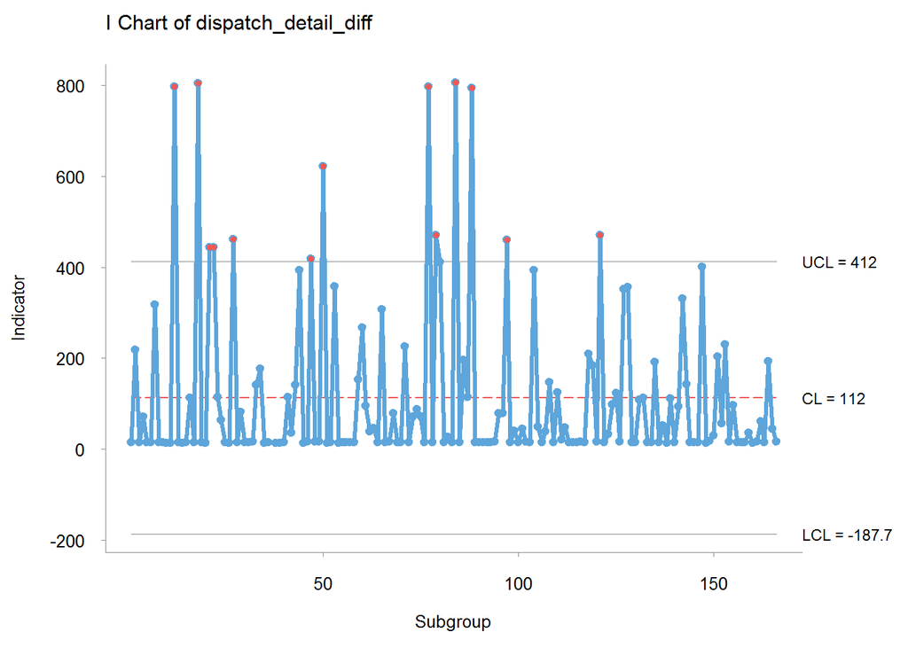

Time from dispatch until scheduled collection for Future Routine orders

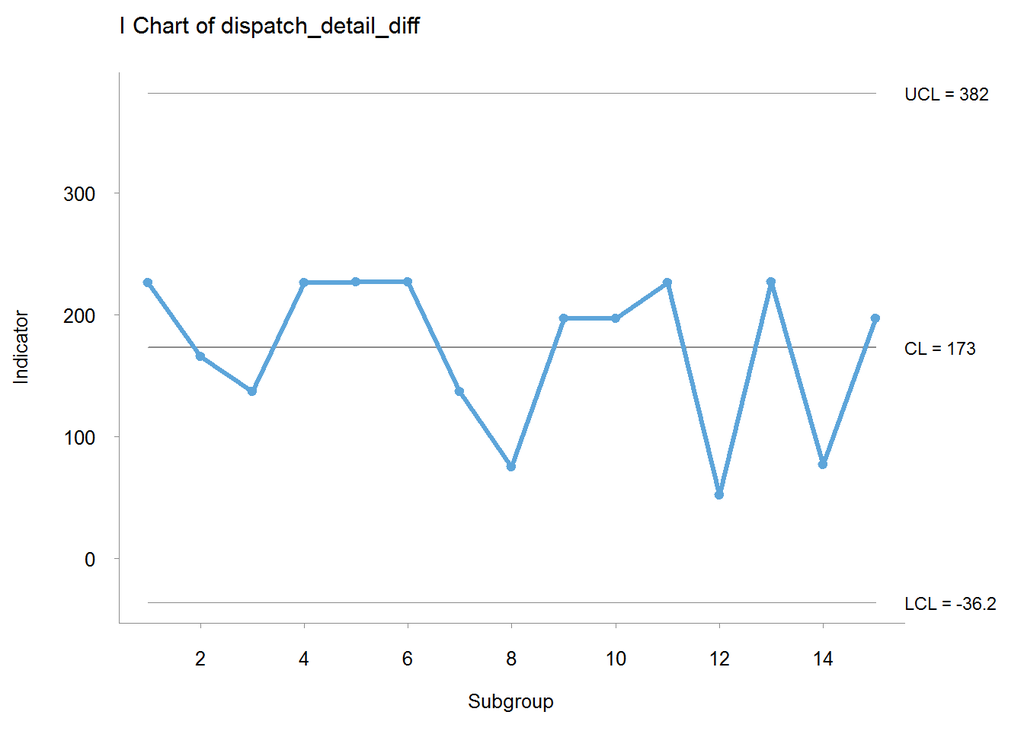

Time from dispatch until scheduled collection for Future Stat orders

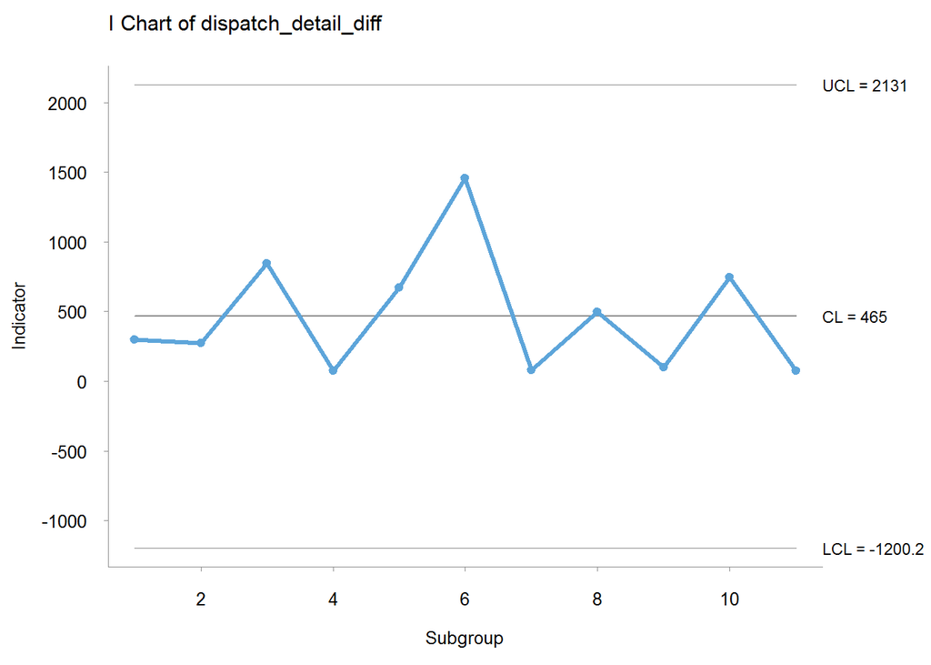

Time from dispatch until scheduled collection for Future Timed Study orders

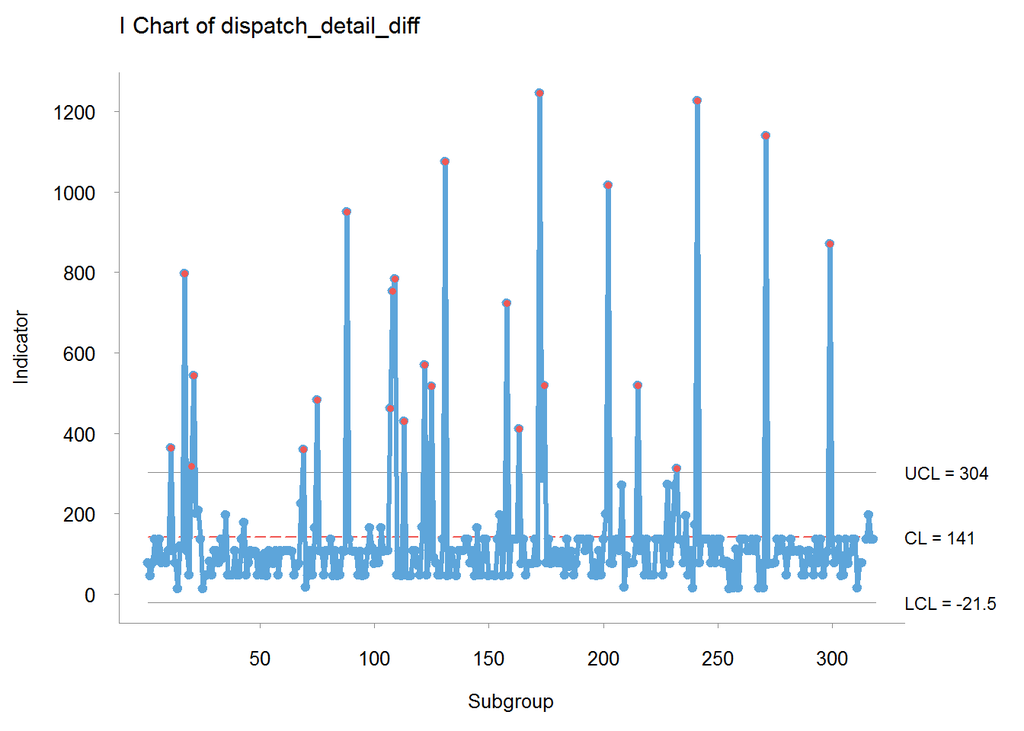

# Correlation Assessment

[interactive chart not shown]

Time between order to scheduled collection and order to dispatch for future orders

There is a strong correlation between the time from order to scheduled collection and the time from order to dispatch.

Correlation between the time from order to scheduled collection and the time from order to dispatch

| type | category | estimate | statistic | p.value | parameter | conf.low | conf.high | method | alternative |
| --- | --- | --- | --- | --- | --- | --- | --- | --- | --- |
| All | All | 0.970 | 105.219 | 0.000 | 691 | 0.965 | 0.974 | Pearson’s product-moment correlation | two.sided |
| Future | All | 0.961 | 78.347 | 0.000 | 506 | 0.954 | 0.967 | Pearson’s product-moment correlation | two.sided |
| Future | Early AM | 0.915 | 28.864 | 0.000 | 163 | 0.885 | 0.936 | Pearson’s product-moment correlation | two.sided |
| Future | Routine | 0.997 | 46.005 | 0.000 | 13 | 0.991 | 0.999 | Pearson’s product-moment correlation | two.sided |
| Future | Stat | 0.284 | 0.890 | 0.397 | 9 | -0.380 | 0.755 | Pearson’s product-moment correlation | two.sided |
| Future | Timed Study | 0.973 | 74.648 | 0.000 | 315 | 0.966 | 0.978 | Pearson’s product-moment correlation | two.sided |
| Now | All | 0.049 | 0.659 | 0.510 | 183 | -0.096 | 0.192 | Pearson’s product-moment correlation | two.sided |
| Now | Routine | 0.147 | 0.711 | 0.484 | 23 | -0.264 | 0.512 | Pearson’s product-moment correlation | two.sided |
| Now | Stat | 0.067 | 0.776 | 0.439 | 135 | -0.102 | 0.232 | Pearson’s product-moment correlation | two.sided |
| Now | Timed Study | -0.203 | -0.950 | 0.353 | 21 | -0.568 | 0.228 | Pearson’s product-moment correlation | two.sided |

[interactive chart not shown]

Time between order to scheduled collection and dispatch to scheduled collection

There is little correlation between the time from order to scheduled collection and time from dispatch to scheduled collection. This suggests that the dispatch time is triggered by the scheduled collection time, regardless of how far in advance the lab is ordered, with the exception of Stat orders which dispatch immediately.

Correlation between the time from order to scheduled collection and time from dispatch to scheduled collection

| type | category | estimate | statistic | p.value | parameter | conf.low | conf.high | method | alternative |
| --- | --- | --- | --- | --- | --- | --- | --- | --- | --- |
| All | All | 0.352 | 9.898 | 0.000 | 691 | 0.285 | 0.416 | Pearson’s product-moment correlation | two.sided |
| Future | All | 0.197 | 4.524 | 0.000 | 506 | 0.112 | 0.279 | Pearson’s product-moment correlation | two.sided |
| Future | Early AM | 0.227 | 2.982 | 0.003 | 163 | 0.077 | 0.367 | Pearson’s product-moment correlation | two.sided |
| Future | Routine | 0.550 | 2.373 | 0.034 | 13 | 0.052 | 0.829 | Pearson’s product-moment correlation | two.sided |
| Future | Stat | 1.000 | 1863.789 | 0.000 | 9 | 1.000 | 1.000 | Pearson’s product-moment correlation | two.sided |
| Future | Timed Study | 0.203 | 3.687 | 0.000 | 315 | 0.095 | 0.307 | Pearson’s product-moment correlation | two.sided |
| Now | All | 0.699 | 13.220 | 0.000 | 183 | 0.617 | 0.766 | Pearson’s product-moment correlation | two.sided |
| Now | Routine | 0.509 | 2.834 | 0.009 | 23 | 0.142 | 0.753 | Pearson’s product-moment correlation | two.sided |
| Now | Stat | 0.986 | 68.807 | 0.000 | 135 | 0.980 | 0.990 | Pearson’s product-moment correlation | two.sided |
| Now | Timed Study | 0.998 | 66.881 | 0.000 | 21 | 0.994 | 0.999 | Pearson’s product-moment correlation | two.sided |

[interactive chart not shown]

Time between dispatch to scheduled collection and scheduled to actual collection

Correlation between the amount of time prior to scheduled collection that the task dispatched and when the lab was actually collected

| type | category | estimate | statistic | p.value | parameter | conf.low | conf.high | method | alternative |
| --- | --- | --- | --- | --- | --- | --- | --- | --- | --- |
| All | All | -0.149 | -3.774 | 0.000 | 631 | -0.224 | -0.071 | Pearson’s product-moment correlation | two.sided |
| Future | All | -0.159 | -3.456 | 0.001 | 458 | -0.247 | -0.069 | Pearson’s product-moment correlation | two.sided |
| Future | Early AM | -0.211 | -2.671 | 0.008 | 153 | -0.357 | -0.055 | Pearson’s product-moment correlation | two.sided |
| Future | Routine | -0.147 | -0.494 | 0.631 | 11 | -0.646 | 0.439 | Pearson’s product-moment correlation | two.sided |
| Future | Stat | 0.382 | 1.239 | 0.247 | 9 | -0.283 | 0.799 | Pearson’s product-moment correlation | two.sided |
| Future | Timed Study | -0.259 | -4.483 | 0.000 | 279 | -0.365 | -0.147 | Pearson’s product-moment correlation | two.sided |
| Now | All | -0.224 | -3.001 | 0.003 | 171 | -0.361 | -0.077 | Pearson’s product-moment correlation | two.sided |
| Now | Routine | -0.182 | -0.890 | 0.383 | 23 | -0.539 | 0.229 | Pearson’s product-moment correlation | two.sided |
| Now | Stat | -0.043 | -0.487 | 0.627 | 127 | -0.214 | 0.131 | Pearson’s product-moment correlation | two.sided |
| Now | Timed Study | -0.347 | -1.526 | 0.145 | 17 | -0.692 | 0.127 | Pearson’s product-moment correlation | two.sided |

# Back-Dated Orders

[interactive chart not shown]

Provider role that ordered back-dated levels

[interactive chart not shown]

Order type used for back-dated levels

# Now vs. Future Orders

[interactive chart not shown]

Orders for future labs by each order priority. Future labs are considered those > 1 hour from the time of ordering.

Early AM orders are categorized as Routine.

[interactive chart not shown]

Provider role placing future orders using Routine or Stat

[interactive chart not shown]

Provider role placing Now orders using Timed Study